# NCBN Salt Marsh Vegetation Monitoring Protocol Review

##### **Introduction**

###### *Previous Analyses*

In 2021, NCBN commissioned a report by Neptune and Company (hereafter referred to as Peck et al. 2021) that evaluates the sampling power of the salt marsh vegetation and nekton monitoring protocols and summarizes trends within a limited subset of the metrics collected as part of these protocols. For the vegetation protocol, the metrics of interest were a multimetric index (MMI) of salt marsh condition developed by Nagel et al. (2017), as well as individual metrics of community composition including the percent cover of Spartina patens and percent cover of high salinity plant species. Power simulations were performed to assess whether the data collected to date were sufficient to detect trends in either the multimetric index or previously listed individual metrics given the large amount of staff time and program money being spent on these protocols. Trends in the multimetric index and the two selected individual metrics for the period of 2008 to 2018 were also quantified using regression analyses. In this section, we have summarized the findings of Peck et al. (2021) and identified limitations of the study that could potentially be addressed by either a) performing additional analyses on the existing data from 2008-2018, or b) restructuring the salt marsh vegetation protocol.

Although Peck et al. (2021) has value as both an assessment of the protocol’s sampling frequency and intensity and as an intial exploratory data analysis, there are large amounts of data that were collected for the salt marsh vegetation monitoring protocol that were not examined in the report. For example, the protocol necessitates recording the presence and cover of every individual species found in every plot, but only a few species are used in the analyses. As such, the analyses contained within Peck et al. (2021) did not consider changes within the context of either a) ecologically significant groups that are known to characterize these habitats, or b) the entire full, comprehensive suite of species that comprise these communities. Given the multivariate nature of the data and the protocol’s focus on monitoring change in biological communities over time, we have identified several potential analyses that could aid in interpreting and drawing conclusions from the existing 2008-2018 data set in the following sections.

##### **Methods**

###### *Site Descriptions*

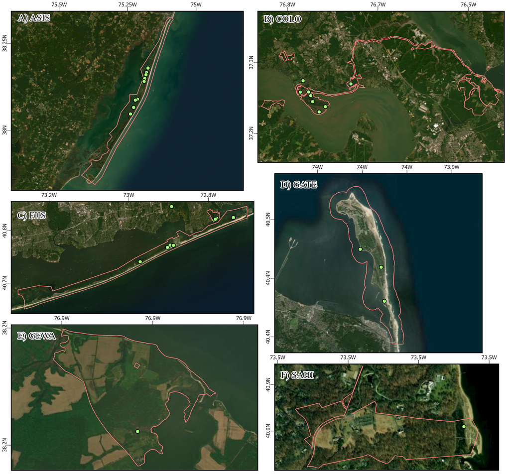

| Table 1. Site count, plot count, monitoring years, and count of sampling events at each park utilizing the NCBN salt marsh vegetation monitoring protocol. Park Unit | Table 1. Site count, plot count, monitoring years, and count of sampling events at each park utilizing the NCBN salt marsh vegetation monitoring protocol. Unit Code | Table 1. Site count, plot count, monitoring years, and count of sampling events at each park utilizing the NCBN salt marsh vegetation monitoring protocol. Location | Table 1. Site count, plot count, monitoring years, and count of sampling events at each park utilizing the NCBN salt marsh vegetation monitoring protocol. Number of Sites | Table 1. Site count, plot count, monitoring years, and count of sampling events at each park utilizing the NCBN salt marsh vegetation monitoring protocol. Site List | Table 1. Site count, plot count, monitoring years, and count of sampling events at each park utilizing the NCBN salt marsh vegetation monitoring protocol. Number of Plots | Table 1. Site count, plot count, monitoring years, and count of sampling events at each park utilizing the NCBN salt marsh vegetation monitoring protocol. Sample Years | Table 1. Site count, plot count, monitoring years, and count of sampling events at each park utilizing the NCBN salt marsh vegetation monitoring protocol. Sampling Events |
| --- | --- | --- | --- | --- | --- | --- | --- |
| Assateague Island National Seashore | ASIS | MD, VA | 9 | A10, A11, A2, A3, A4, A5, A6, A8, A9 | 2,125 | 2008, 2010, 2012, 2014, 2016, 2018 | 6 |
| Colonial National Historical Park | COLO | VA | 8 | C1, C13, C19, C23, C30, C5, C6, C8 | 1,043 | 2008, 2010, 2012, 2014, 2016 | 5 |
| Fire Island National Seashore | FIIS | NY | 9 | F1, F2, F3, F4, F5, F6, WF1, WF2, WF3 | 2,395 | 2009, 2011, 2013, 2015, 2017 | 5 |
| Gateway National Recreation Area | GATE | NJ, NY | 3 | GSH1, GSH2, GSH3 | 413 | 2010, 2012, 2014, 2016, 2018 | 5 |
| George Washington Birthplace National Monument | GEWA | VA | 1 | G1 | 140 | 2008, 2010, 2012 | 3 |
| Sagamore Hill National Historic Site | SAHI | NY | 1 | SAG1 | 225 | 2009, 2011, 2013, 2015, 2017 | 5 |

###### *Data Analyses*

In many instances, the total percent cover was recorded as adding to over 100%. In order to standardize the percent cover values between plots, we converted the percent cover of each species to relative percent cover by dividing the percent cover of each species in a plot by the total plant cover of the entire plot. The frequency of occurrence for each species was calculated as the proportion of plots at a site in which a species was found.  
We compared changes in the salt marsh plant community over time within the 6 park units using the following 5 metrics: average total plot cover, average plot-level species richness, maximum plot-level species richness, total park-level species richness, and the number of species unique to each park. Average plot-level species richness represents the average number of species recorded in each plot. Maximum plot-level species richness was derived from the plot with the highest species richness found among all plots at each park. Total park-level species richness was calculated as the total number of distinct species found across all plots at each park. The number of unique species at each park represents the count of species at a park that were not found at the other 5 parks.  
With the exception of total park-level species richness and the number of unique species at each park, we first calculated the value of each metric for each plot within each site for each year, and then averaged these plot-level values up to the site-level for each year. Comparisons over time within each park are presented as line graphs with the sample years on the x-axis and the respective metric on the y-axis, with separate panels for each park unit. Error values and error bars represent the standard error of the site-level yearly values for the 5 previously mentioned metrics.  
Since salinity is known to be a key factor controlling plant community composition in coastal wetlands, we also compared changes in the count, frequency, and relative percent cover of species with low, medium, and high salinity tolerance over time in each park. We used the salinity tolerance categories from the USDA plants database to categorize each species as either low (< 0.5 ppt), medium (0.5 to 18 ppt), or high (> 18 ppt) salinity tolerance. Note that there were several species (47 out of 156) that did not have salinity tolerance classifications in the USDA plants database.  
Finally, we compared changes in plant community composition over time at each park using permutational multivariate analysis of variance using distance matrices (ADONIS) via the ‘adonis2’ function from the R package ‘vegan.’ Although an analysis of similarities (a.k.a. ANOSIM) was recommended for trend analysis in the original NCBN salt marsh vegetation monitoring protocol, we opted to use the ADONIS model since ANOSIM can potentially confound the differences between groups with the dispersion within groups (Warton et al., 2012). For parks where the ADONIS model detected a significant difference between years, we used then post-hoc pairwise comparisons with Bonferroni corrections via the function ‘pairwise.adonis’ in the R package ‘pairwiseAdonis’ to find the year-pairs with significant differences. Finally, we used the ‘kruskal.test’ function from the R package ‘stats’ to find the species with significantly different relative percent cover for the year pairs identified in the previous pairwise comparisons.

*Note to Sarah - I just noticed that the protocol also suggests comparisons based on cover type - I’ll work on that when I get back from ASIS but I expect that it will show results similar to the salinity tolerance comparisons.*

##### **Results**

###### *Total Cover*

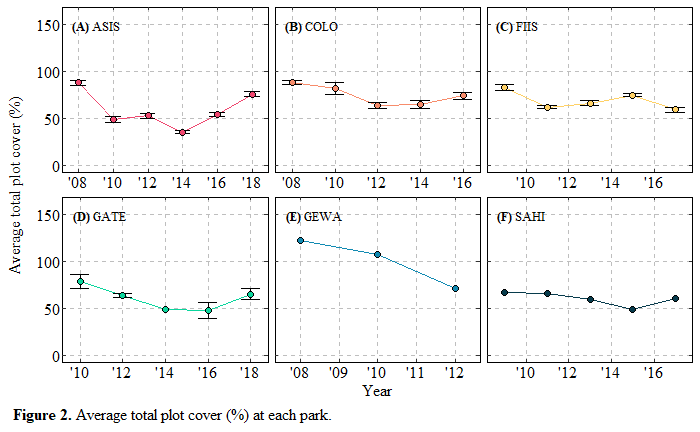

###### *Species Richness*

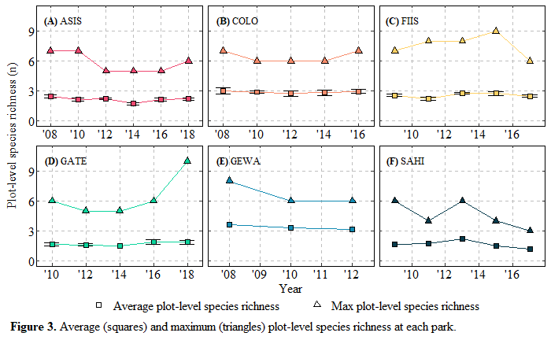

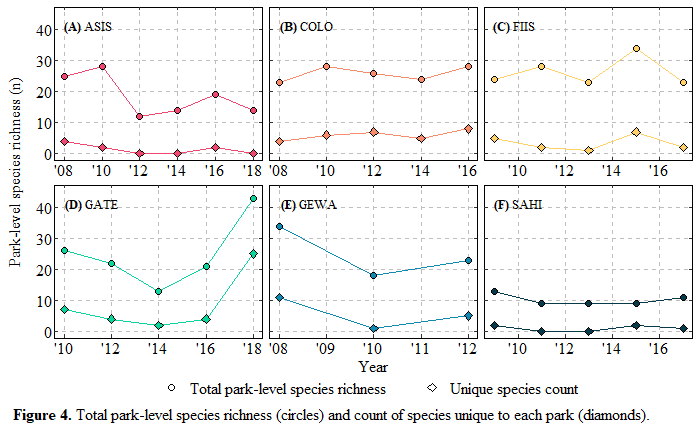

###### *Invasive, Noxious & Prohibited Species*

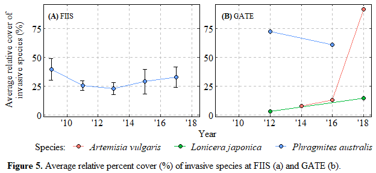